# Part II - (Effects of Given Loan Classifiers or Variables on the Loan Status, Amount and BorrowerAPR)

## by (Eze, Obinna Joshua Miguel)

## Investigation Overview

> I will show the effect of the loan classifiers such as selected qualititative variables (employment status, occupation, prosper alpha rating) and numeric variables (borrower apr, term, monthly loan payment, stated monthly income) on either or both the loan amount and the loan status.

## Dataset Overview

> The dataset has 113,937 loans with a total of 81 variables, such as loan amount, loan status, borrower annual percentage rate (interest rate), current loan status, borrower income, and many more in the original dataset.

## Distribution of Loan Original Amount

The loan original amount given to listed borrowers has a wide range of values from 1000 to 35000. This variable when plotted using a logarithmic scale it has a multimodal distribution

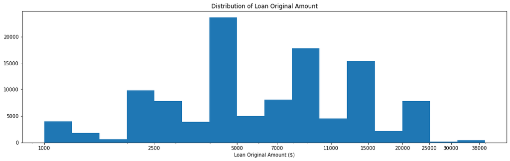

## Description of Loan Status

Loan status gives the current status of the loan with the following values Cancelled, Chargedoff, Completed, Current, Defaulted, FinalPaymentInProgress and PastDue.

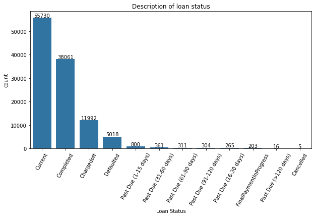

## Loan Original Amount by Employment Status, Prosper Rating Alpha and Occupation

Also seen is that occupations with the highest average and actual loan original amount are amongst professionals, starting with Judges, Pharmacist, Doctors and so on. This is interesting because the Judge occupation as seen in the univariate analysis had the second to lowest count of listed borrowers, only above the student occupation. Yet the borrowed the highest loan and has the highest average of all loans they took. Those with the lowest average original loan amount are students.

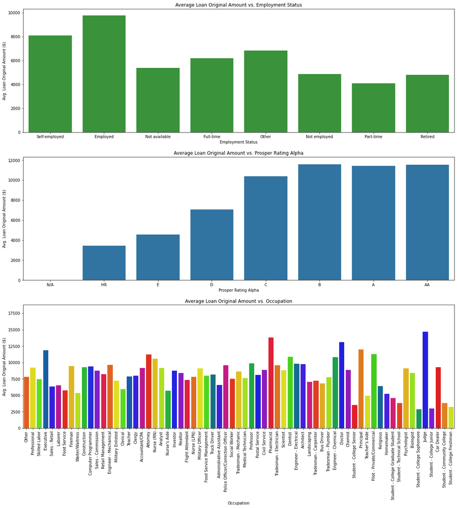

## Loan Original Amount by Prosper Rating Alpha and Term

in this visualization the term increases from 12-36-60 and so too does the amount given as loan to the borrowers. Interesting the prosper rating alpha stays true only for the term of 60 with the highest loan amount being for AA and the lowest for E.

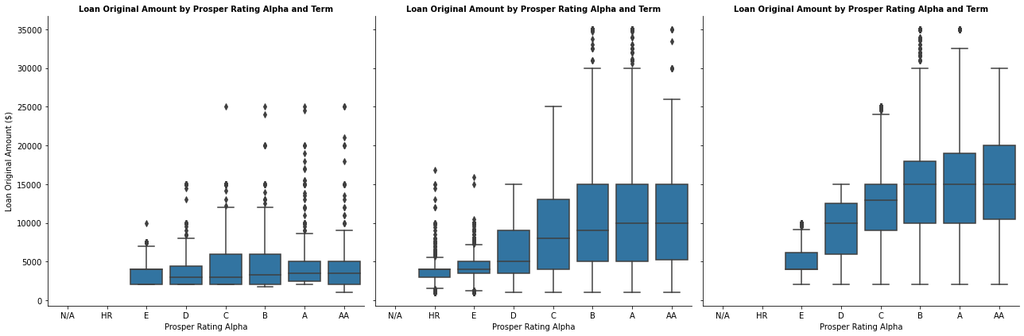

## Loan Status, Loan Original Amount vs. Prosper Rating Alpha, Term and Employment Status

Considering that a lot of listed borrowers fall within the loan status of current and completed, this analysis will be restricted to only these loan statuses.

The prosper rating is valid as it corresponds to borrowers who receive equivalent loan amounts and as seen frequency or count of the completed and current loan status diminishes as the prosper rating frops from AA to HR and as the Loan original amount drops too.

The loan status whether completed or current has a higher average loan original amount as the term increases.

The employed completed more of their loans and with a larger average loan original amount. They also have more current loans at a larger average loan original amount. The part-time has the least completed loans at the lowest average loan original amount.

[figure not shown]

## Loan Original Amount by Employment Status and Term

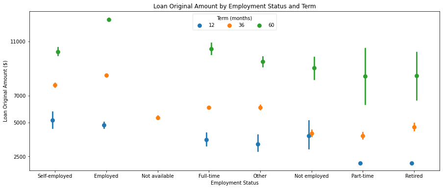